# 1 Axe 1: Les conditions de vie et les inégalités sociales

## 1.1 Immigration et diversité ethnoculturelle

Chaque année, Laval accueille des milliers de nouveaux·elles arrivant·e·s, illustrant une tendance constante d’augmentation de la population immigrante au cours des 25 dernières années. Cette croissance souligne le rôle de Laval comme destination majeure pour les immigrant·e·s au Québec. En effet, la proportion de la population lavalloise qui est composée d’immigrant·e·s a augmenté de façon significative au cours des 25 dernières années, et plus particulièrement depuis 2001 (voir le graphique 1.1 ci-dessous)[^1].

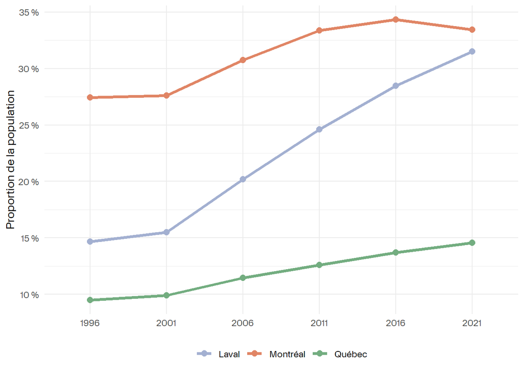

Selon le recensement de 2021, près d’un tiers (31,5 %) de la population de Laval est constituée d’immigrant·e·s, contre 33,4 % à Montréal et 14,6 % dans l’ensemble du Québec. Le graphique 1.2 ci-dessous montre la répartition spatiale de la population immigrée de Laval, avec des proportions plus élevées dans et autour du Secteur d’aménagement Chomedey.

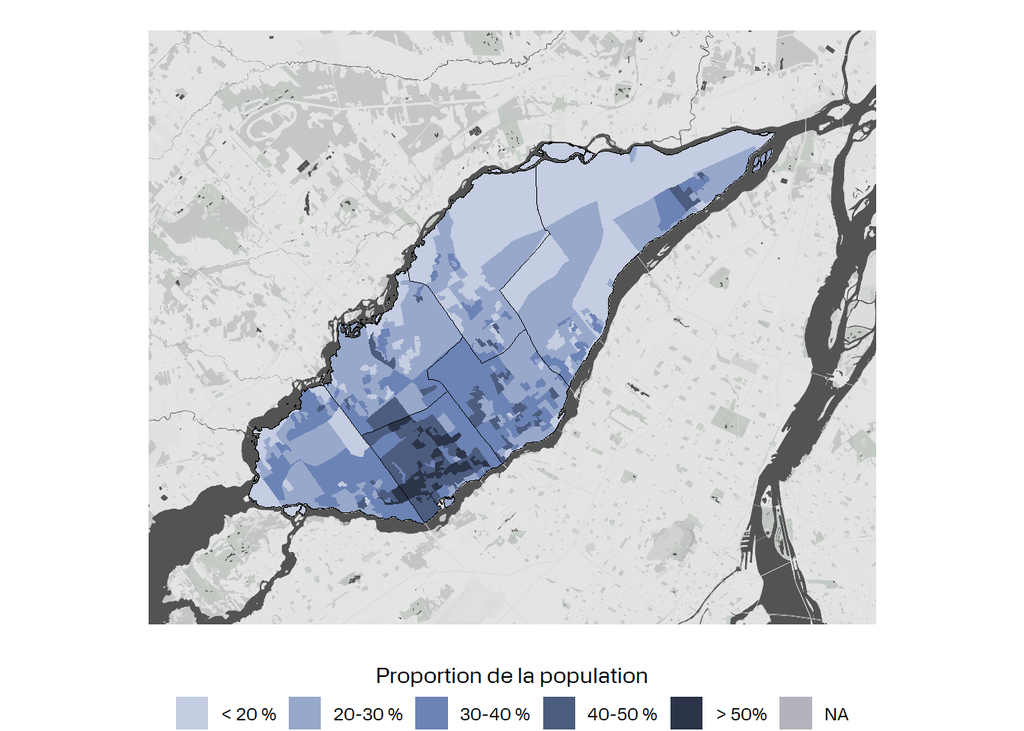

Figure 1.2: Proportion d’immigrants dans la population, 2021

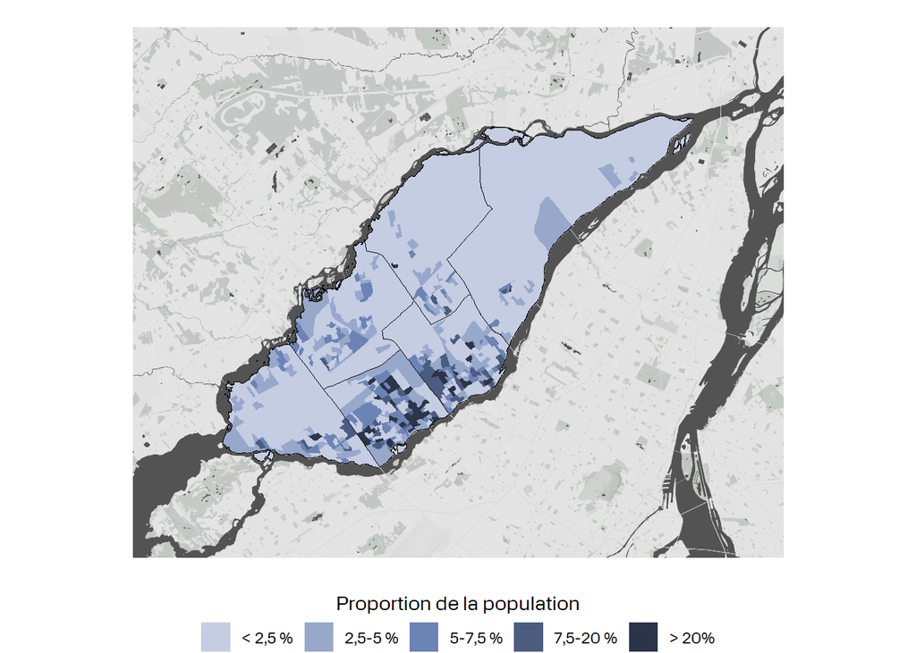

Figure 1.3: Proportion d’immigrants récents dans la population, 2021

### 1.1.1 Les statuts d’immigrant·e·s

Les résidents non permanents ne représentent qu’une très faible proportion de la population, soit environ (1,2 %) des résidents.

| Région | Population (n) | Immigrants totaux (n) | Immigrants totaux (%) | Immigrants récents (n) | Immigrants récents (%) | Résident non permanents (n) | Résident non permanents (%) | Non-immigrants (n) | Non-immigrants (%) |
| --- | --- | --- | --- | --- | --- | --- | --- | --- | --- |
| Laval | 429 600 | 135 300 | 31,5 % | 16 200 | 3,8 % | 5 310 | 1,2 % | 288 900 | 67,3 % |
| Montréal | 1 723 200 | 576 100 | 33,4 % | 104 000 | 6 % | 129 780 | 7,5 % | 1 017 300 | 59 % |
| Québec | 8 308 500 | 1 210 600 | 14,6 % | 202 700 | 2,4 % | 205 770 | 2,5 % | 6 892 100 | 83 % |

Définition: Immigrant·e récent·e - *Un·e immigrant·e récent·e est un·e immigrant·e qui a obtenu le droit d’établissement moins de 5 ans avant le recensement de 2021* [^2]

Définition: Résident·e non permanent - *Résident·e non permanent·e désigne une personne d’un autre pays dont le lieu de résidence habituel est le Canada et qui est titulaire d’un permis de travail ou d’un permis d’études ou qui a demandé le statut de réfugié (demandeur d’asile).* [^3]

### 1.1.2 Citoyenneté

Bien que les niveaux d’immigration soient plus élevés à Laval que dans le reste de la province, les taux de citoyenneté sont toutefois similaires. En effet, la grande majorité des résident·e·s de Laval (93,1 %) sont des citoyen·ne·s canadien·ne·s, une proportion similaire à l’ensemble du Québec (93,8 %), et plus élevée qu’à Montréal (83,2 %) [^4]

### 1.1.3 Période d’immigration

Définition: Période d’immigration - *La période d’immigration désigne la période pendant laquelle l’immigrant·e a obtenu son statut d’immigrant·e reçu ou de résident permanent pour la première fois.* [^5]

Le graphique 1.4 illustre la répartition de la proportion de la population immigrante totale à Laval et au Québec en fonction de la période d’arrivée. Chaque barre représente la proportion de la population immigrante totale actuelle qui a immigré au cours de chaque période spécifiée.

En ce qui concerne la population immigrante lavalloise, l’afflux le plus important s’est produit entre 2001 et 2010, cette décennie représentant le pourcentage le plus élevé de la population immigrante actuelle. [^6]

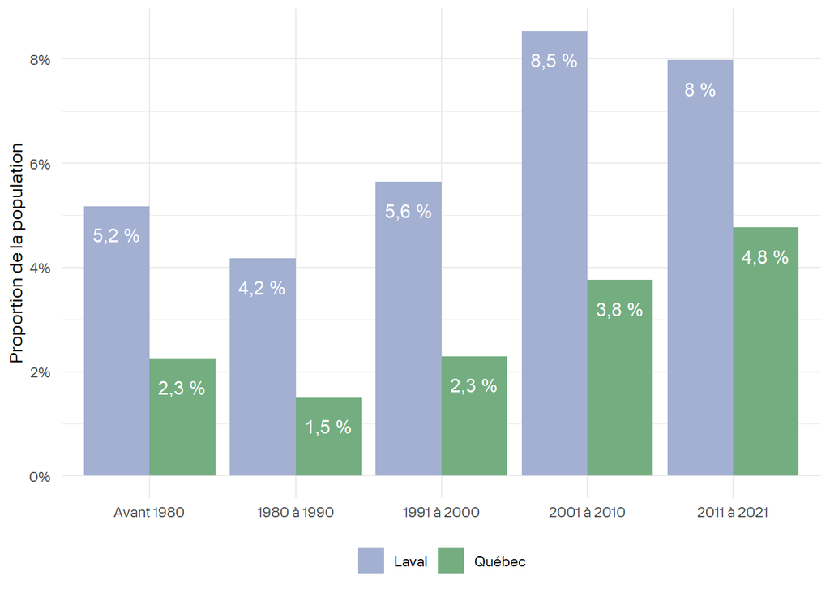

Figure 1.4: Période d’immigration, Laval et Québec

### 1.1.5 Catégorie d’admission

La population immigrante de Laval peut être mieux comprise en fonction de sa catégorie d’admission et de son expérience de pré-admission. Les quatre catégories d’admission sont les suivantes : immigrant·e économique, immigrant·e parrainé par la famille, réfugié·e et autre. À Laval, similaire à l’ensemble du Québec, la moitié (49,7 %) de la population immigrante appartient à la catégorie de l’immigration économique. [^7] Cela signifie qu’ils ont été sélectionnés en raison de leur potentiel à contribuer à l’économie canadienne en répondant aux besoins du marché du travail, en gérant des entreprises, en faisant des investissements ou en répondant à des demandes spécifiques régionales. Comparativement à la province, Laval compte une plus grande proportion de réfugié·e·s au sein de sa population immigrante.

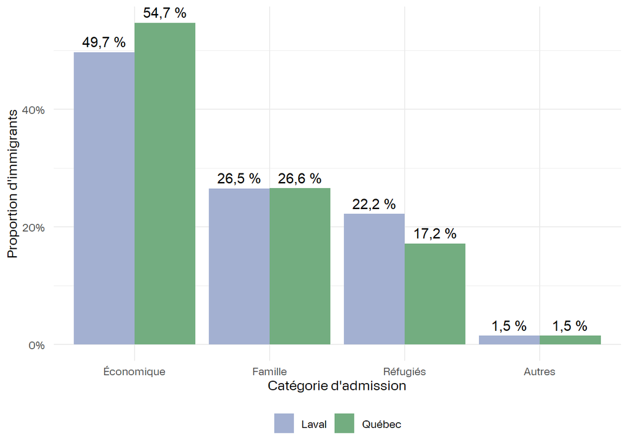

Figure 1.5: Population immigrée par catégorie d’admission, 2021

Note. Catégorie d’admission et type de demandeur pour la population immigrée dans les ménages privés qui a été admise entre 1980 et 2021.

### 1.1.6 Âge à l’immigration

Le groupe d’âge le plus représenté parmi les résident·e·s immigrant·e·s est de loin celui des 25 à 44 ans. Bien que toutes les catégories d’âge montrent un équilibre entre les genres, la catégorie des 15 à 24 ans ne respecte pas cette tendance. En effet, il y a plus de femmes que d’hommes qui immigrent dans le groupe d’âge des jeunes adultes et adolescents, comme au niveau des 45 ans et plus, bien qu’à plus petite proportion.

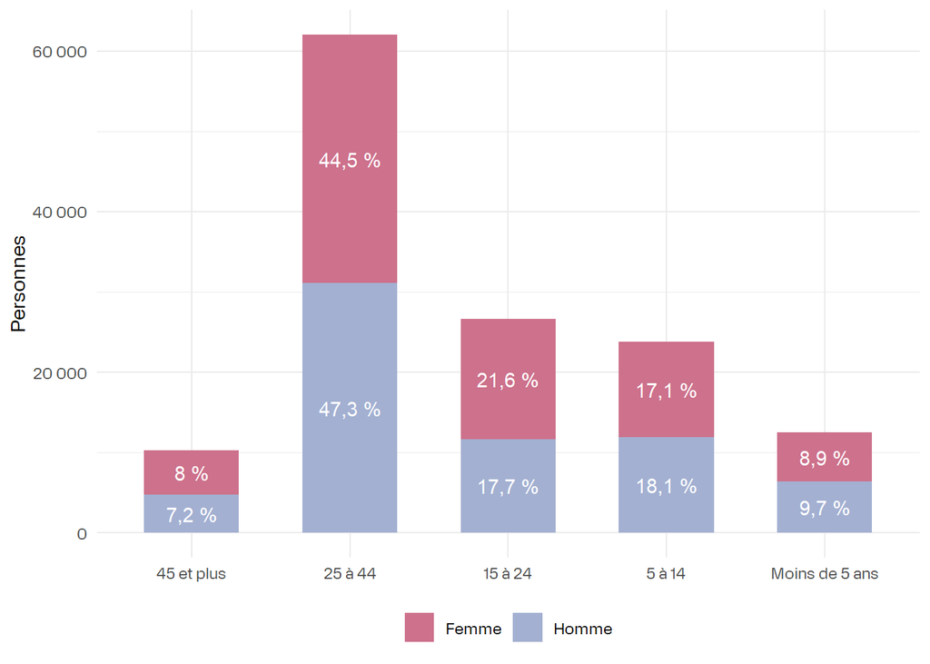

Figure 1.6: Âge à l’immigration, 2021

### 1.1.7 Origines ethniques

La population immigrante de Laval est diversifiée, contribuant à la variété démographique de la ville. Avant 1980, la plupart des immigrant·e·s de Laval venaient d’Italie, de Grèce ou d’Haïti. Au fil des années, les origines des nouveaux·elles arrivant·e·s à Laval ont changé. En 2021, un·e immigrant·e sur trois (35,4 %) était né·e dans un pays d’Asie (y compris le Moyen-Orient) [^8]. Les autres immigrant·e·s proviennent principalement de pays africains (23 %), de pays européens (21,9 %) et des Caraïbes ou d’Amérique centrale, du Sud et latine (18,7 %).

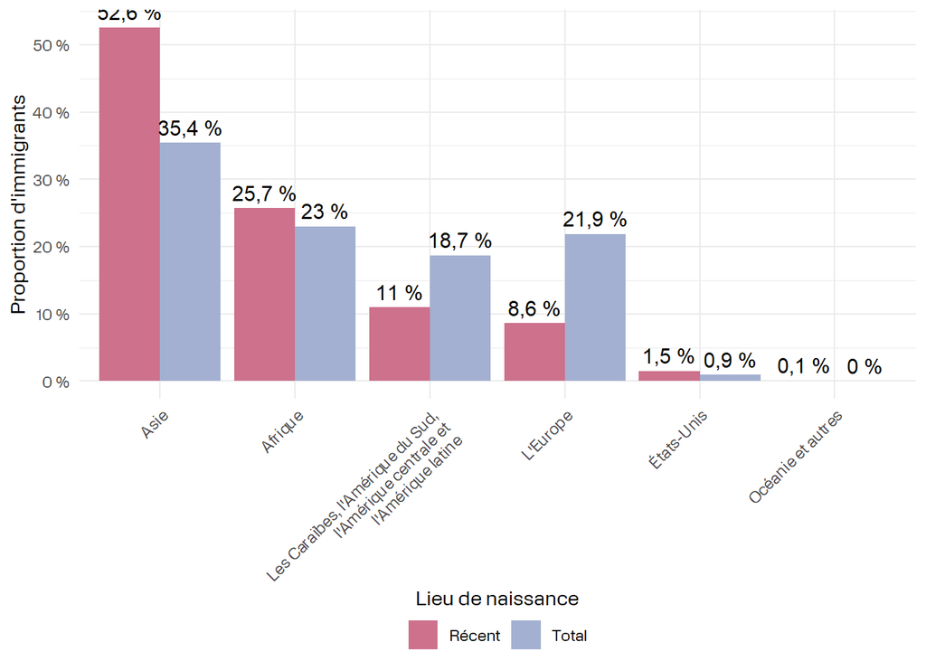

Figure 1.7: Lieu de naissance de la population immigrée totale par rapport à la population immigrée récente

### 1.1.8 Minorités visibles

Définition: Minorité visible - *Une personne appartenant à une minorité visible est une personne, autre qu’un autochtone, qui ne sont pas de race blanche ou qui n’ont pas la peau blanche.* [^10]

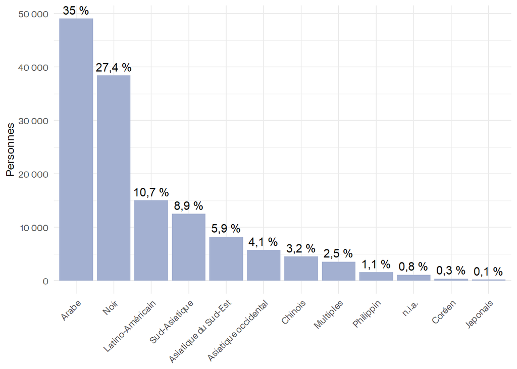

Figure 1.8: Répartition de la population appartenant à une minorité visible. N.i.a = Réponse écrite, 2021

### 1.1.9 Appartenance religieuse

Les résident·e·s laïques ou non religieux représentent 18 % de la population lavalloise, tandis qu’au Québec, plus de 27,3 % de la population est laïque ou non religieuse. La religion la plus répandue à Laval est le christianisme, qui représente près des deux tiers (65,4 %) de la population (64,8 % pour la province) [^11]. La deuxième religion la plus répandue à Laval est l’islam, qui représente 12,9 % de la population, comparativement à la province où elle ne représente qu’environ 5,1 %.

[^1]: Statistique Canada. (2022). Tableau 98-10-0307-01 Statut d’immigrant et période d’immigration selon le lieu de naissance : Canada, provinces et territoires, divisions de recensement et subdivisions de recensement. Récupéré de https://doi.org/10.25318/9810030701-fra
[^2]: Statistique Canada. (2017). Recensement de la population de 2016 : Immigration et diversité ethnoculturelle. Récupéré de https://www12.statcan.gc.ca/census-recensement/2016/ref/98-501/98-501-x2016008-fra.cfm
[^3]: Statistique Canada. (2021). Dictionnaire, Recensement de la population, 2021. Récupéré de https://www12.statcan.gc.ca/census-recensement/2021/ref/dict/az/Definition-fra.cfm?ID=pop253
[^4]: Statistique Canada. (2023). Tableau 98-10-0360-01 Pays de citoyenneté selon le genre et l’âge : Divisions de recensement. Récupéré de https://doi.org/10.25318/9810036001-fra
[^5]: Statistique Canada. (2021). Dictionnaire, Recensement de la population, 2021. Récupéré de https://www12.statcan.gc.ca/census-recensement/2021/ref/dict/az/Definition-fra.cfm?ID=pop109
[^6]: Statistique Canada. (2022). Statut d’immigrant et période d’immigration selon le lieu de naissance : Canada, provinces et territoires, divisions de recensement et subdivisions de recensement. Récupéré de https://doi.org/10.25318/9810030701-fra
[^7]: Statistique Canada. (2022). Dictionnaire, Recensement de la population, 2021. Récupéré de https://www12.statcan.gc.ca/census-recensement/2021/ref/dict/az/Definition-fra.cfm?ID=pop169
[^8]: Statistique Canada. (2023). Tableau 98-10-0350-01 Lieu de naissance et période d’immigration selon le genre et l’âge : Divisions de recensement. Récupéré de https://doi.org/10.25318/9810035001-fra
[^9]: Statistique Canada. (2023). Tableau 98-10-0352-03 Minorité visible selon le genre et l’âge : Subdivisions de recensement ayant une population de 5 000 habitants ou plus. Récupéré de https://doi.org/10.25318/9810035201-fra
[^10]: Statistique Canada. (2021). Minorité visible de la personne. Récupéré de https://www23.statcan.gc.ca/imdb/p3Var_f.pl?Function=DECI&Id=1323413
[^11]: Statistique Canada. (2023). Tableau 98-10-0354-03 Religion selon le genre et l’âge : Subdivisions de recensement ayant une population de 5 000 habitants ou plus. Récupéré de https://doi.org/10.25318/9810035401-fra